# PROYECCIÓN DE LOS ESTUDIANTES DE LA UNIVERSIDAD DE INGENIERIA Y TECNOLOGIA PARA REALIZAR ESTUDIOS DE POSGRADO EN UNIVERSIDADES DENTRO Y FUERA DEL PERÚ DURANTE EL AÑO 2023.

```r
table(ZZ$Modalidad_ExtrangeroS)
```

```
##
##                   Con una beca Yo solventare todos los gastos
##                             86                             31
```

```r
unique(ZZ$Modalidad_ExtrangeroS)
```

```
## [1] "Con una beca"                   NA
## [3] "Yo solventare todos los gastos"
```

```r
variable_sin_na <- na.omit(ZZ$Modalidad_ExtrangeroS)

# Clonando la base de datos
Modalidad_ExtrangeroS2.0 <- data.frame(variable_sin_na)
Modalidad_ExtrangeroS2.0
```

| variable_sin_na |
| --- |
| Con una beca |
| Con una beca |
| Con una beca |
| Con una beca |
| Con una beca |
| Con una beca |
| Yo solventare todos los gastos |
| Con una beca |
| Con una beca |
| Con una beca |

[output cut: 107 more lines]

```r
table(ZZ$Modalidad_ExtrangeroS)
```

```
##
##                   Con una beca Yo solventare todos los gastos
##                             86                             31
```

AHORA ANALICEMOS LOS GASTOS MENSUALES EN DOLARES

```r
ZZ$gastos_mensuales_dolares
```

```
##   [1] 4500 4000   NA 5000   NA   NA 4000 2500 4000   NA   NA 2500   NA 2500   NA
##  [16]   NA   NA   NA   NA   NA   NA 2000 2500   NA   NA   NA 1500 1500   NA 3000
##  [31]   NA   NA   NA 2000   NA 1000   NA 1500 5000 5000 4000   NA 2000   NA 3000
##  [46] 4500 3500 1500   NA 5000 4500 3000 1500   NA   NA 1500 2000 1000   NA   NA
##  [61] 5000 1500 2500   NA 2500   NA   NA 2000   NA 3000 3500 2000   NA 3000 2500
##  [76]   NA   NA 1000 2500 3500 2500   NA   NA   NA   NA 1000 3500   NA 3000   NA
##  [91] 3000 5000 2000 5000 1000   NA   NA 4000 2000 3500 2500   NA   NA   NA 1500
## [106]   NA 4500 1000   NA   NA 4500 5000   NA   NA   NA 1500 1500 2000 1500 2000
## [121]   NA   NA   NA   NA   NA   NA 4000 4500 2500 2500   NA 1000   NA 3500 1500
## [136] 1000   NA   NA 5000   NA 1000   NA 2500 1500 1500   NA 2500   NA 2500   NA
## [151] 5000   NA   NA 2500 2500   NA 2500   NA   NA 2000   NA 4000 2500   NA   NA
## [166] 2000   NA 1500 3500 3000 3000 1500 2000 3500   NA   NA 2000   NA 3500 5000
## [181]   NA 2000   NA   NA 3000 3500 3000 1500   NA   NA   NA   NA 5000 1000   NA
## [196] 5000 3000   NA   NA   NA 4500   NA   NA 1000 5000 2500   NA   NA 4500   NA
## [211] 2000 5000 2000   NA 5000   NA   NA
```

```r
table(ZZ$gastos_mensuales_dolares)
```

```
##
## 1000 1500 2000 2500 3000 3500 4000 4500 5000
##   11   17   17   20   12   10    7    8   16
```

```r
unique(ZZ$gastos_mensuales_dolares)
```

```
##  [1] 4500 4000   NA 5000 2500 2000 1500 3000 1000 3500
```

```r
variable_sin_na <- na.omit(ZZ$gastos_mensuales_dolares)

# Clonando la base de datos
gastos_mensuales_dolares2.0 <- data.frame(variable_sin_na)
gastos_mensuales_dolares2.0
```

| variable_sin_na |
| --- |
| 4500 |
| 4000 |
| 5000 |
| 4000 |
| 2500 |
| 4000 |
| 2500 |
| 2500 |
| 2000 |
| 2500 |

[output cut: 108 more lines]

```r
table(ZZ$gastos_mensuales_dolares)
```

```
##
## 1000 1500 2000 2500 3000 3500 4000 4500 5000
##   11   17   17   20   12   10    7    8   16
```

**CONOCE SOBRE LOS GASTOS DE VIAJE**

```r
ZZ$gastos_viaje
```

```
##   [1] "Si" "Si" NA   "No" NA   NA   "Si" "No" "Si" NA   NA   "No" NA   "No" NA
##  [16] NA   NA   NA   NA   NA   NA   "Si" "Si" NA   NA   NA   "No" "Si" NA   "No"
##  [31] NA   NA   NA   "No" NA   "Si" NA   "No" "Si" "No" "Si" NA   "No" NA   "Si"
##  [46] "No" "Si" "No" NA   "Si" "No" "No" "No" NA   NA   "Si" "No" "No" NA   NA
##  [61] "Si" "Si" "No" NA   "No" NA   NA   "No" NA   "No" "No" "No" NA   "No" "Si"
##  [76] NA   NA   "No" "No" "Si" "Si" NA   NA   NA   NA   "No" "No" NA   "No" NA
##  [91] "No" "Si" "No" "Si" "No" NA   NA   "No" "Si" "No" "No" NA   NA   NA   "No"
## [106] NA   "Si" "Si" NA   NA   "Si" "No" NA   NA   NA   "No" "No" "No" "No" "Si"
## [121] NA   NA   NA   NA   NA   NA   "Si" "No" "No" "No" NA   "No" NA   "No" "Si"
## [136] "Si" NA   NA   "No" NA   "No" NA   "No" "No" "No" NA   "Si" NA   "Si" NA
## [151] "Si" NA   NA   "No" "No" NA   "Si" NA   NA   "No" NA   "Si" "No" NA   NA
## [166] "No" NA   "No" "No" "Si" "Si" "No" "Si" "Si" NA   NA   "No" NA   "No" "No"
## [181] NA   "No" NA   NA   "No" "No" "Si" "No" NA   NA   NA   NA   "Si" "No" NA
## [196] "No" "Si" NA   NA   NA   "Si" NA   NA   "No" "No" "No" NA   NA   "No" NA
## [211] "No" "No" "Si" NA   "Si" NA   NA
```

```r
unique(ZZ$gastos_viaje)
```

```
## [1] "Si" NA   "No"
```

```r
table(ZZ$gastos_viaje)
```

```
##
## No Si
## 74 44
```

**CONOCE SOBRE LOS PROCESOS**

```r
ZZ$Conoce_procesos
```

```
##   [1] "Si"      "No"      "Si"      "No"      "No"      "No"      "Si"
##   [8] "No"      "Si"      "Si"      "No"      "Un Poco" "Si"      "No"
##  [15] "No"      "Si"      "No"      "No"      "Si"      "Si"      "No"
##  [22] "Si"      "Si"      "No"      "Si"      "No"      "Si"      "No"
##  [29] "No"      "Si"      "No"      "Si"      "No"      "No"      "Si"
##  [36] "Si"      "No"      "Si"      "Si"      "No"      "Si"      "No"
##  [43] "No"      "No"      "No"      "Si"      "Si"      "No"      "No"
##  [50] "Si"      "No"      "No"      "No"      "Si"      "Si"      "No"
##  [57] "Si"      "Si"      "Si"      "No"      "Si"      "No"      "Si"
##  [64] "Si"      "No"      "No"      "Si"      "No"      "No"      "No"
##  [71] "No"      "Si"      "Si"      "Si"      "No"      "No"      "No"
##  [78] "Si"      "Si"      "No"      "Si"      "No"      "Si"      "Si"
##  [85] "Si"      "No"      "No"      "No"      "Si"      "No"      "Si"
##  [92] "Si"      "Si"      "Si"      "Si"      "No"      "No"      "No"
##  [99] "Si"      "Si"      "Si"      "No"      "Si"      "Si"      "Si"
```

[output cut: 16 more lines]

```r
table(ZZ$Conoce_procesos)
```

```
##
##      No      Si Un Poco
##      92     106       7
```

```r
ZZ <- ZZ %>%
  mutate_if(is.numeric, as.integer)
```

```r
str(ZZ)
```

```
## tibble [217 x 20] (S3: tbl_df/tbl/data.frame)
##  $ Carrera                                                                           : chr [1:217] "Ingeniería Electrónica" "Ciencia de la Computación" "Ingeniería Electrónica" "Bioingeniería" ...
##  $ Genero                                                                            : chr [1:217] "Masculino" "Masculino" "Masculino" "Femenino" ...
##  $ Edad                                                                              : int [1:217] 20 18 19 20 20 20 21 19 19 22 ...
##  $ Ciclo                                                                             : int [1:217] 4 3 4 4 4 4 7 4 6 4 ...
##  $ O_merito                                                                          : chr [1:217] "Tercio Superior" "Décimo Superior" "Décimo Superior" "Quinto Superior" ...
##  $ Cachimbo                                                                          : int [1:217] 2021 2022 2021 2019 2021 2021 2019 2021 2021 2021 ...
##  $ Promedio                                                                          : int [1:217] 14 17 14 18 16 14 14 16 16 14 ...
##  $ Condi_socio                                                                       : chr [1:217] "Bajo" "Medio Bajo" "Bajo" "Medio Bajo" ...
##  $ Ingreso_mensualITO                                                                : int [1:217] 1200 2000 1200 2000 2000 2500 2500 2000 3100 1200 ...
##  $ Realiza_Posgrado                                                                  : chr [1:217] "Sí" "Sí" "Sí" "Sí" ...
##  $ Peru_o_extrangero                                                                 : chr [1:217] "Extranjero" "Extranjero" "Perú" "Extranjero" ...
##  $ U_del_Peru                                                                        : chr [1:217] NA NA "PUCP" NA ...
##  $ Modalidad_peru                                                                    : chr [1:217] NA NA "Con una beca" NA ...
##  $ gastos_mensuales_soles                                                            : int [1:217] NA NA 5000 NA 3000 3000 NA NA NA 1000 ...
##  $ U_del_Extran                                                                      : chr [1:217] "MIT" "UPM" NA "MIT" ...
##  $ gastos_mensuales_dolares                                                          : int [1:217] 4500 4000 NA 5000 NA NA 4000 2500 4000 NA ...
##  $ gastos_viaje                                                                      : chr [1:217] "Si" "Si" NA "No" ...
##  $ Modalidad_ExtrangeroS                                                             : chr [1:217] "Con una beca" "Con una beca" NA "Con una beca" ...
##  $ Conoce_procesos                                                                   : chr [1:217] "Si" "No" "Si" "No" ...
##  $ ¿Tienes conocimientos procesos que se siguen para continuar estudios de postgrado?: logi [1:217] NA NA NA NA NA NA ...
```

# 2. ANALISIS DESCRIPTIVO

Bien ahora con los datos limpios vamos con los descriptores

```r
library(dplyr)
```

**DESCRIPTOR ESTADISTICO PARA LA VARIABLE CARRERA**

```r
carrera_descriptivos <- ZZ %>%
  summarise(
    cantidad_carreras = n_distinct(Carrera),
    carreras_mas_comunes = toString(sort(table(Carrera), decreasing = TRUE)[1:3])
  )
```

```r
print(carrera_descriptivos)
```

```
## # A tibble: 1 x 2
##   cantidad_carreras carreras_mas_comunes
##               <int> <chr>
## 1                14 52, 35, 25
```

```r
# Descriptores estadísticos para la variable 'Genero' (chr), es una categorica ordinal
genero_descriptivos <- ZZ %>%
  summarise(
    cantidad_generos = n_distinct(Genero),
    genero_mas_comun = names(sort(table(Genero), decreasing = TRUE))[1]
  )

print(genero_descriptivos)
```

```
## # A tibble: 1 x 2
##   cantidad_generos genero_mas_comun
##              <int> <chr>
## 1                2 Masculino
```

```r
# Descriptores estadísticos para la variable 'Edad' (int)
edad_descriptivos <- ZZ %>%
  summarise(
    edad_minima = min(Edad),
    edad_maxima = max(Edad),
    edad_promedio = mean(Edad),
    edad_mediana = median(Edad),
    edad_desviacion = sd(Edad)
  )
```

```r
print(edad_descriptivos)
```

```
## # A tibble: 1 x 5
##   edad_minima edad_maxima edad_promedio edad_mediana edad_desviacion
##         <int>       <int>         <dbl>        <int>           <dbl>
## 1          15          32          19.9           19            1.99
```

**VARIABLE AÑO DE INGRESO**

```r
# Calcular tabla de frecuencias para la variable "Cachimbo"
tabla <- table(ZZ$Cachimbo)

# Mostrar la tabla de frecuencias
print(tabla)
```

```
##
## 2017 2018 2019 2020 2021 2022 2023
##    6    7   17   22  112   51    2
```

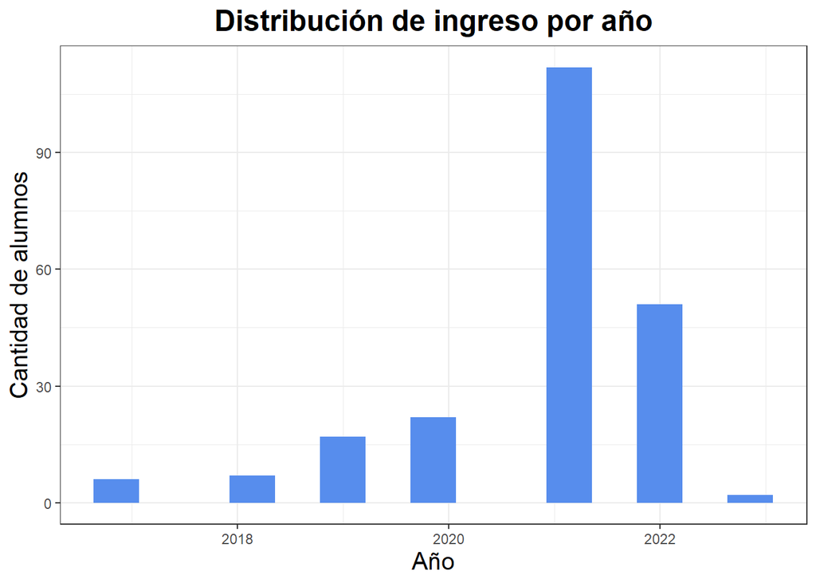

```r
library(ggplot2)
# Gráfico de barras para la variable "Cachimbo"
ggplot(ZZ) +
  aes(x = Cachimbo) +
  geom_histogram(bins = 15L, fill = "#578DED") +
  labs(
    x = "Año",
    y = "Cantidad de alumnos",
    title = "Distribución de ingreso por año"
  ) +
  theme_bw() +
  theme(
    plot.title = element_text(size = 18L,
    face = "bold",
    hjust = 0.5),
    axis.title.y = element_text(size = 15L),
    axis.title.x = element_text(size = 15L)
  )
```

```r
moda <- function(x) {
  tbl <- table(x)
  moda_valores <- tbl[tbl == max(tbl)]
  return(as.numeric(names(moda_valores)))
}
moda <- moda(ZZ$Cachimbo)
moda
```

```
## [1] 2021
```

**PROMEDIO PONDERADO**

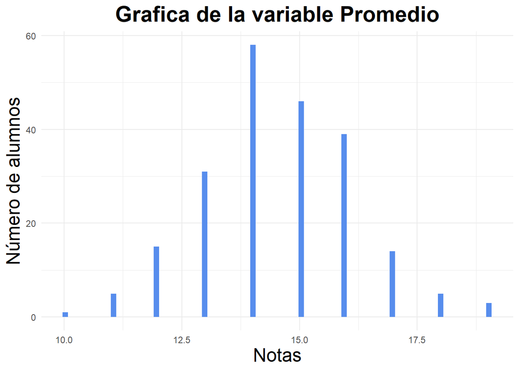

```r
library(ggplot2)

tabla <- table(ZZ$Promedio)



# Gráfico de barras para la variable "Promedio Ponderado"
library(ggplot2)
ggplot(ZZ) +
  aes(x = Promedio) +
  geom_histogram(bins = 80L, fill = "#578DED") +
  labs(
    x = "Notas",
    y = "Número de alumnos",
    title = "Grafica de la variable Promedio"
  ) +
  theme_minimal() +
  theme(
    plot.title = element_text(size = 21L,
    face = "bold",
    hjust = 0.5),
    axis.title.y = element_text(size = 18L),
    axis.title.x = element_text(size = 18L)
  )
```

**CONDICION SOCIOECONOMICA**

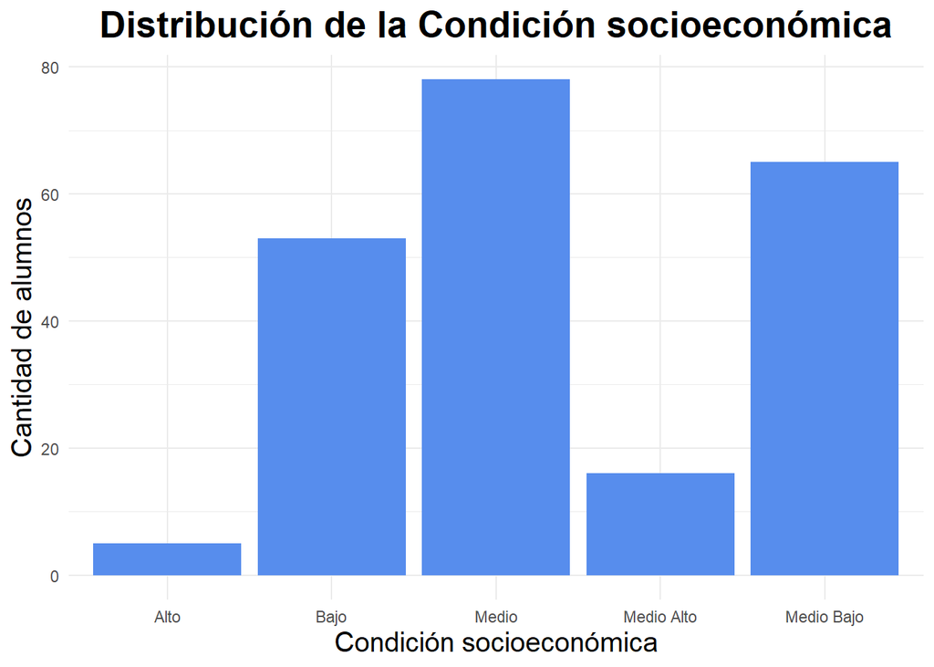

```r
ZZ %>%
 filter(!is.na(Condi_socio)) %>%
 ggplot() +
  aes(x = Condi_socio) +
  geom_bar(position = "dodge", fill = "#578DED") +
  labs(
    x = "Condición socioeconómica",
    y = "Cantidad de alumnos",
    title = "Distribución de la Condición socioeconómica"
  ) +
  theme_minimal() +
  theme(
    plot.title = element_text(size = 20L,
    face = "bold",
    hjust = 0.5),
    axis.title.y = element_text(size = 15L),
    axis.title.x = element_text(size = 15L)
  )
```

**INGRESOS MENSUALES**

```r
# Descriptores estadísticos para la variable 'Ingreso_mensualito' (int)
ingreso_mensual_descriptivos <- ZZ %>%
  summarise(
    Ingreso_minima = min(Ingreso_mensualITO),
    Ingreso_maxima = max(Ingreso_mensualITO),
    El_Ingreso_promedio = mean(Ingreso_mensualITO),
    La_mediana_del_ingreso = median(Ingreso_mensualITO),
    Ingreso_desviacion = sd(Ingreso_mensualITO)
  )

print(ingreso_mensual_descriptivos)
```

```
## # A tibble: 1 x 5
##   Ingreso_minima Ingreso_maxima El_Ingreso_promedio La_mediana_del_ingreso
##            <int>          <int>               <dbl>                  <int>
## 1           1200          12100               2311.                   2000
## # i 1 more variable: Ingreso_desviacion <dbl>
```

```r
#Incluso puedo hacer un grafico

# Calcular tabla de frecuencias para la variable "Ingreso_mensual"
tabla <- table(ZZ$Ingreso_mensualITO)

# Mostrar la tabla de frecuencias
print(tabla)
```

```
##
##  1200  1600  1800  2000  2500  2800  3000  3100  4100  5100  6100  9100 12100
##    53    18    24    23    32    21    25     6     6     4     2     2     1
```

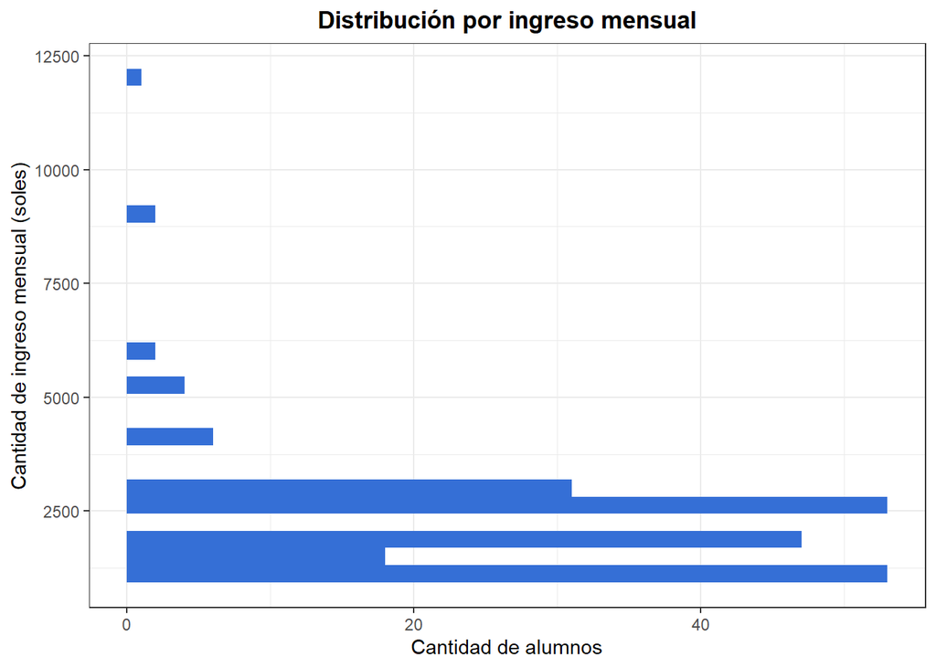

```r
# Gráfico de barras para la variable "Cachimbo"
ggplot(ZZ) +
  aes(x = Ingreso_mensualITO) +
  geom_histogram(bins = 30L, fill = "#356FD6") +
  labs(
    x = "Cantidad de ingreso mensual (soles)",
    y = "Cantidad de alumnos",
    title = "Distribución por ingreso mensual"
  ) +
  coord_flip() +
  theme_bw() +
  theme(plot.title = element_text(face = "bold", hjust = 0.5))
```

**AHORA ANALIZEMOS DE TODA LA POBLACION ENTREVISTADA LOS QUE VAN A REALIZAR POSGADO Y LOS QUE NO VAN A REALIZAR POSGRADO**

```r
# Calcular la tabla de frecuencias para la variable "Realiza_Posgrado"
tabla <- table(ZZ$Realiza_Posgrado)

# Calcular el porcentaje de cada categoría
porcentaje_SI <- (tabla["Sí"] / sum(tabla)) * 100
porcentaje_NO <- (tabla["No"] / sum(tabla)) * 100

# Mostrar los resultados
print(paste("Porcentaje de 'Si':", porcentaje_SI, "%"))
```

```
## [1] "Porcentaje de 'Si': 82.4884792626728 %"
```

```r
print(paste("Porcentaje de 'No':", porcentaje_NO, "%"))
```

```
## [1] "Porcentaje de 'No': 17.5115207373272 %"
```

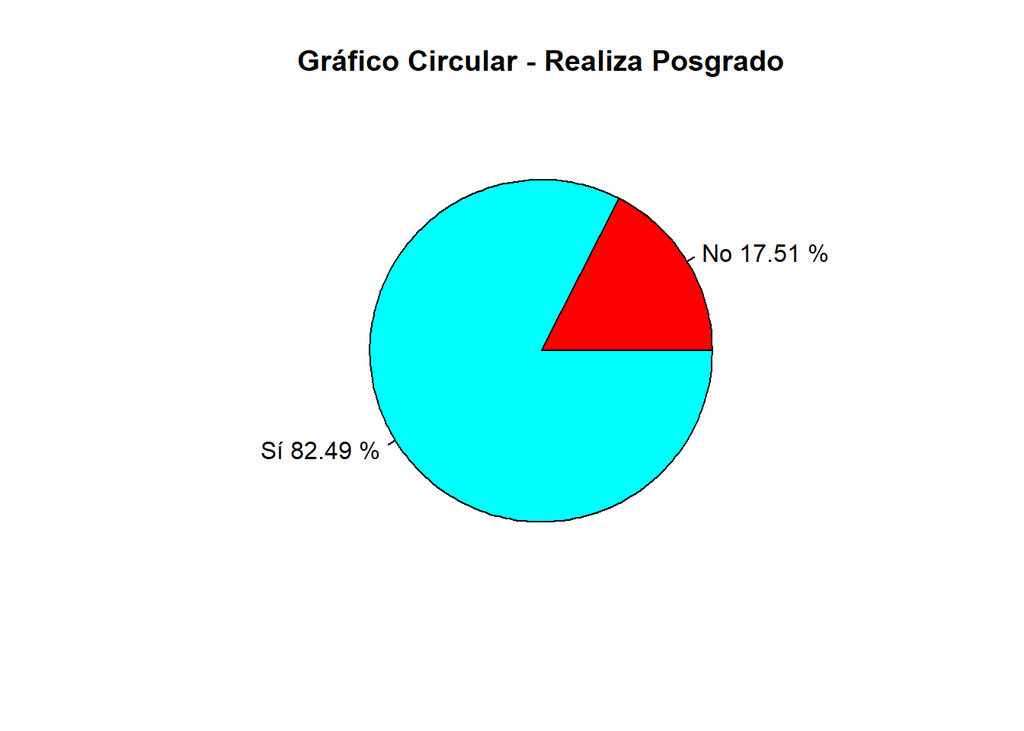

```r
# Crear una tabla de frecuencias de la variable Realiza_Posgrado
tabla <- table(ZZ$Realiza_Posgrado)

# Calcular los porcentajes de cada categoría
porcentajes <- round(prop.table(tabla) * 100, 2)

# Etiquetas de las categorías
etiquetas <- names(tabla)

# Crear el gráfico circular
pie(tabla, labels = paste(etiquetas, porcentajes, "%", sep = " "),
    col = rainbow(length(etiquetas)), main = "Gráfico Circular - Realiza Posgrado")
```

**AHORA ANALICEMOS LA VARIABLE, que indica el lugar en el que va a realizar posgrado ya sea en el peru o en el extranjero**

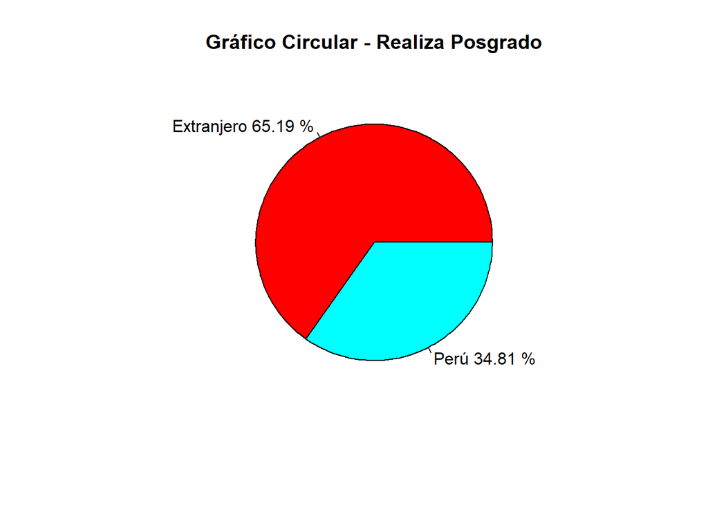

```r
# Gráfico de barras para la variable "Cachimbo"
tabla <- table(ZZ$Peru_o_extrangero)

# Calcular los porcentajes de cada categoría
porcentajes <- round(prop.table(tabla) * 100, 2)

# Etiquetas de las categorías
etiquetas <- names(tabla)

# Crear el gráfico circular
pie(tabla, labels = paste(etiquetas, porcentajes, "%", sep = " "),
    col = rainbow(length(etiquetas)), main = "Gráfico Circular - Realiza Posgrado")
```

**GRAFICA DE LAS UNIVERSIDADES DEL PERÚ**

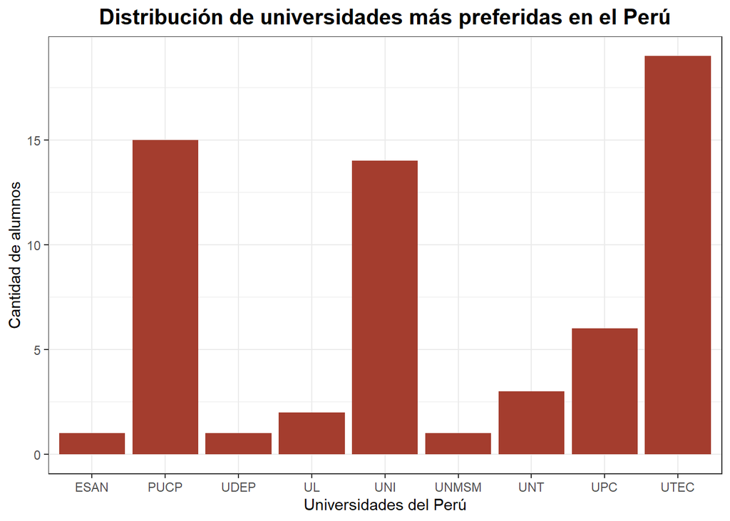

```r
ZZ %>%
 filter(!(U_del_Peru %in% "PUPC") & !is.na(U_del_Peru)) %>%
 ggplot() +
  aes(x = U_del_Peru) +
  geom_bar(fill = "#A43D2E") +
  labs(
    x = "Universidades del Perú",
    y = "Cantidad de alumnos",
    title = "Distribución de universidades más preferidas en el Perú"
  ) +
  theme_bw() +
  theme(
    plot.title = element_text(size = 15L,
    face = "bold",
    hjust = 0.5)
  )
```

**GRAFICA DE UNIVERSIDADES DEL EXTRANJERO**

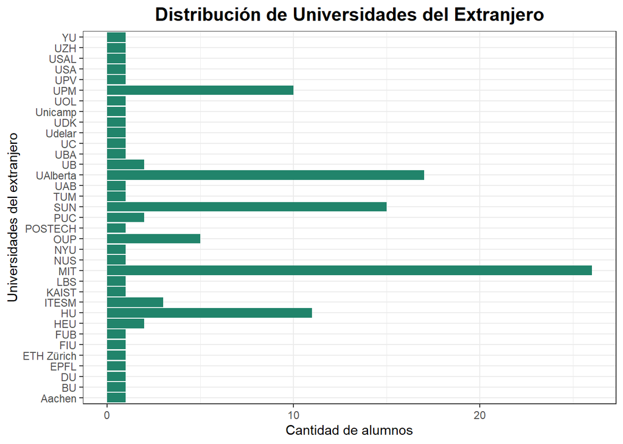

```r
library(dplyr)
library(ggplot2)

ZZ %>%
 filter(!is.na(U_del_Extran)) %>%
 ggplot() +
 aes(x = U_del_Extran) +
 geom_bar(fill = "#21846B") +
 labs(x = "Universidades del extranjero",
 y = "Cantidad de alumnos", title = "Distribución de Universidades del Extranjero") +
 coord_flip() +
 theme_bw() +
 theme(plot.title = element_text(size = 15L, face = "bold", hjust = 0.5))
```

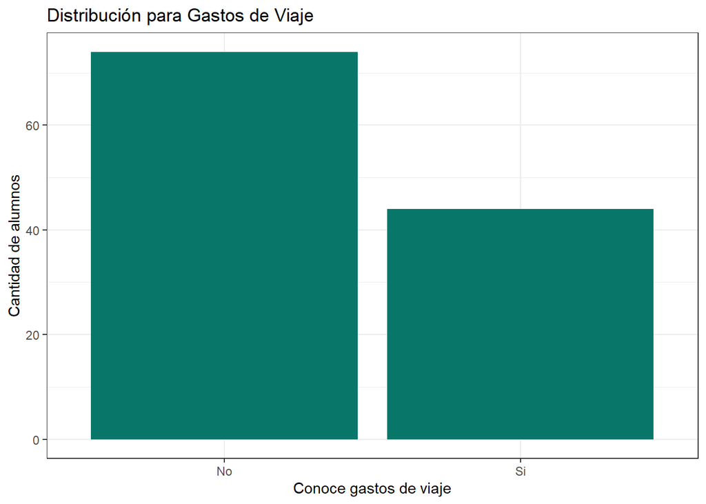

```r
ZZ %>%
 filter(!is.na(gastos_viaje)) %>%
 ggplot() +
  aes(x = gastos_viaje) +
  geom_bar(fill = "#087769") +
  labs(
    x = "Conoce gastos de viaje",
    y = "Cantidad de alumnos",
    title = "Distribución para Gastos de Viaje"
  ) +
  theme_bw()
```

**modalidad en el Perù**

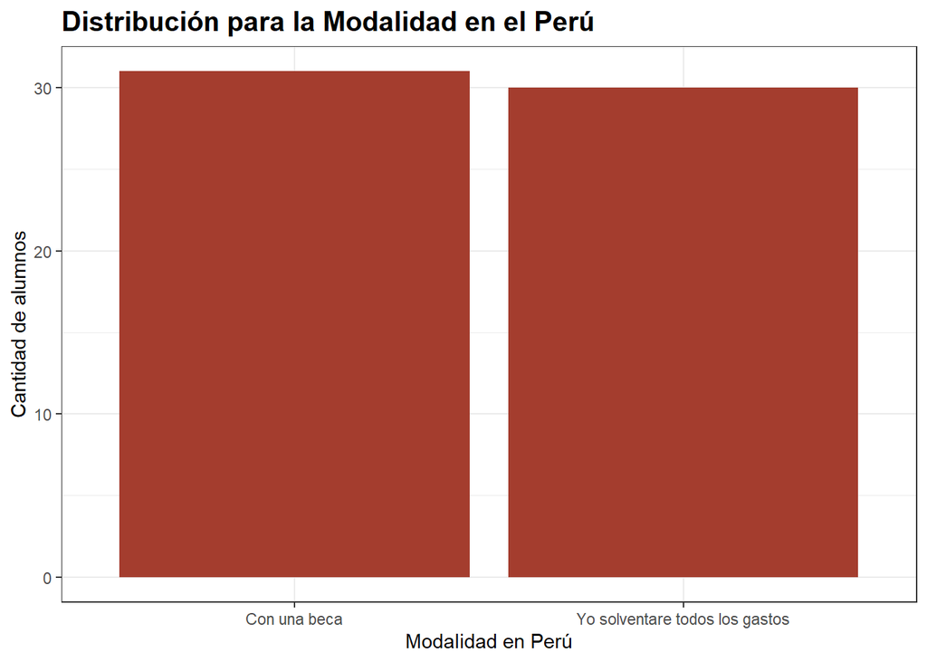

```r
# Gráfico de barras para la variable "Cachimbo"
ZZ %>%
 filter(!is.na(Modalidad_peru)) %>%
 ggplot() +
  aes(x = Modalidad_peru) +
  geom_bar(fill = "#A43D2E") +
  labs(
    x = "Modalidad en Perú",
    y = "Cantidad de alumnos",
    title = "Distribución para la Modalidad en el Perú"
  ) +
  theme_bw() +
  theme(plot.title = element_text(size = 15L, face = "bold"))
```

**Variable Extranjero**

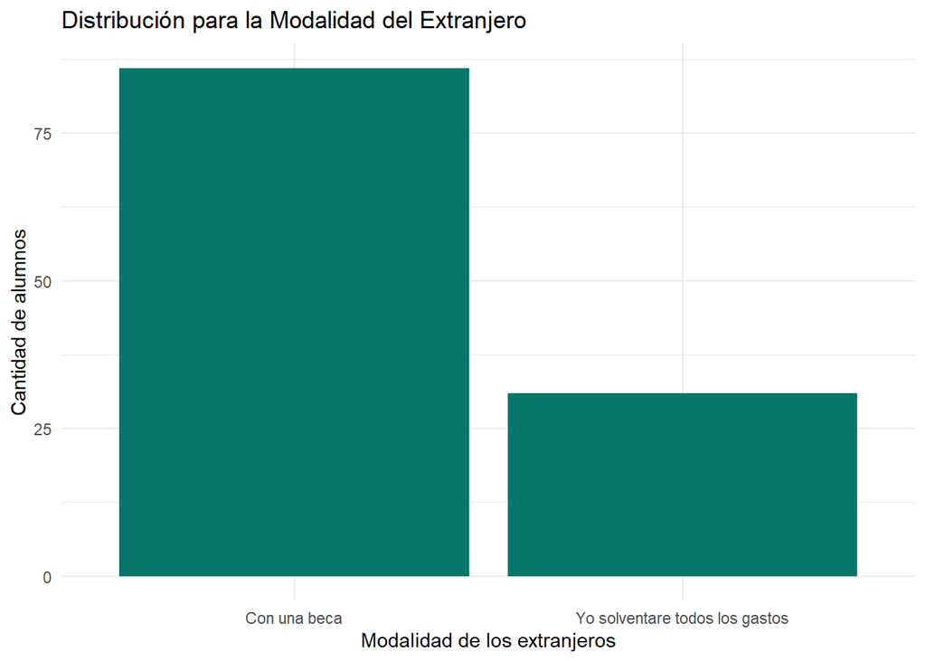

```r
# Gráfico de barras para la variable "Cachimbo"
ZZ %>%
 filter(!is.na(Modalidad_ExtrangeroS)) %>%
 ggplot() +
  aes(x = Modalidad_ExtrangeroS) +
  geom_bar(fill = "#087769") +
  labs(
    x = "Modalidad de los extranjeros",
    y = "Cantidad de alumnos",
    title = "Distribución para la Modalidad del Extranjero"
  ) +
  theme_minimal()
```

**GASTOS EN SOLES**

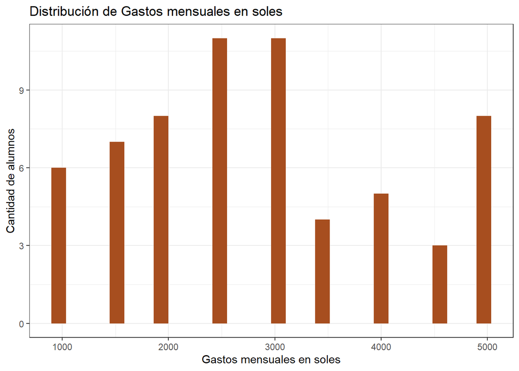

```r
# Gráfico de barras para la variable "Cachimbo"
ggplot(ZZ) +
  aes(x = gastos_mensuales_soles) +
  geom_histogram(bins = 30L, fill = "#A74E1F") +
  labs(
    x = "Gastos mensuales en soles",
    y = "Cantidad de alumnos",
    title = "Distribución de Gastos mensuales en soles"
  ) +
  theme_bw()
```

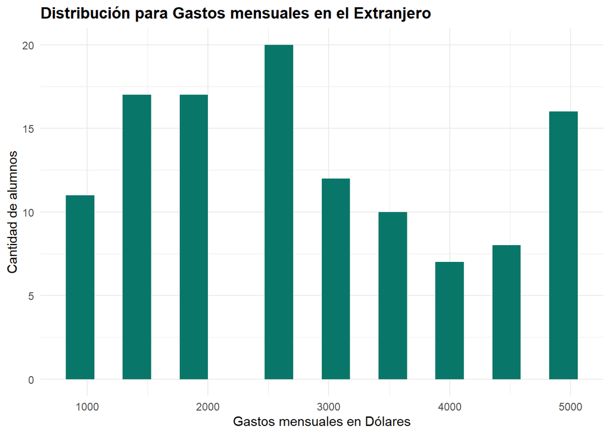

```r
# Gráfico de barras para la variable "Cachimbo"
ggplot(ZZ) +
  aes(x = gastos_mensuales_dolares) +
  geom_histogram(bins = 18L, fill = "#087769") +
  labs(
    x = "Gastos mensuales en Dólares",
    y = "Cantidad de alumnos",
    title = "Distribución para Gastos mensuales en el Extranjero"
  ) +
  theme_minimal() +
  theme(plot.title = element_text(face = "bold"))
```

```r
library(ggplot2)
```

**VARIABLE CONOCE SOBRE LOS PROCESOS**

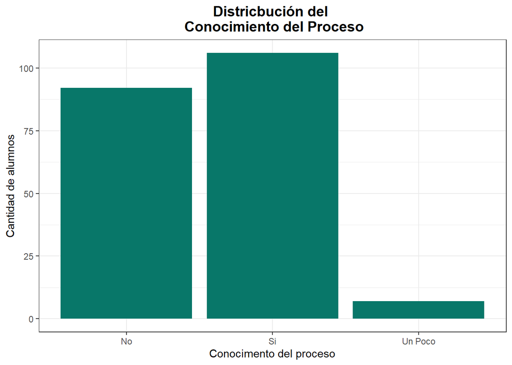

```r
# Gráfico de barras para la variable "Conoce_procesos"
library(dplyr)
library(ggplot2)

ZZ %>%
 filter(!is.na(Conoce_procesos)) %>%
 ggplot() +
 aes(x = Conoce_procesos) +
 geom_bar(fill = "#087769") +
 labs(x = "Conocimento del proceso",
 y = "Cantidad de alumnos", title = "Districbución del
 Conocimiento del Proceso") +
 theme_bw() +
 theme(plot.title = element_text(size = 14L,
 face = "bold", hjust = 0.5))
```

**1 OBJETIVO** Para cuantificar la cantidad de estudiantes según desean estudiar o no sus estudios de posgrado, con las carreras que estudian: analizaremos las variables “Carrera” y “Realiza_Posgrado”.

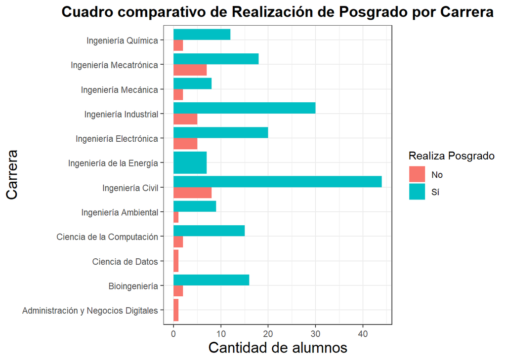

```r
ZZ %>%
 filter(!(Carrera %in% c("Ingenieria Electronica", "Ingenieria Mecatronica"))) %>%
 ggplot() +
  aes(x = Carrera, fill = Realiza_Posgrado) +
  geom_bar(position = "dodge") +
  scale_fill_hue(direction = 1) +
  labs(
    y = "Cantidad de alumnos",
    title = "Cuadro comparativo de Realización de Posgrado por Carrera", fill = "Realiza Posgrado"
  ) +
  coord_flip() +
  theme_bw() +
  theme(
    plot.title = element_text(size = 15L,
    face = "bold",
    hjust = 0.5),
    axis.title.y = element_text(size = 15L),
    axis.title.x = element_text(size = 15L)
  )
```

De acuerdo a la gráfica de barras “Realización de posgrado por carrera”, se puede interpretar que estudiantes de Ingeniería Civil e Industrial predominan en nuestra encuesta. Esto nos sirve para conocer mejor a nuestra población y no tiene una mayor relevancia para nuestro estudio. Además, respecto a la variable cualitativa nominal (Realiza_Posgrado)podemos observar que todos los estudiantes de las carreras Ciencia de Datos y Administración y Negocios Digitales no realizarán posgrado, sin embargo, el 100% de los estudiantes de Ingeniería de la Energía , sí realizarán posgrado.

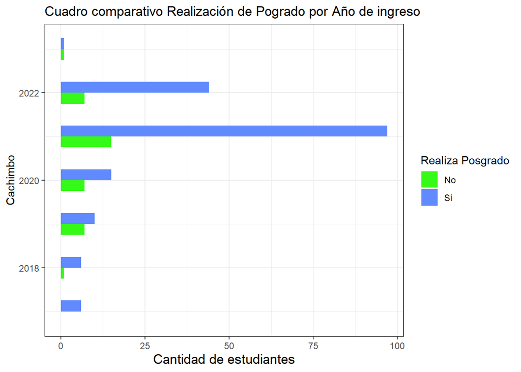

```r
library(ggplot2)

ggplot(ZZ) +
 aes(x = Cachimbo, fill = Realiza_Posgrado) +
 geom_histogram(bins = 13L, position = "dodge") +
 scale_fill_manual(values = c(No = "#35F916", Sí = "#618AFF")) +
 labs(y = "Cantidad de estudiantes",
 title = "Cuadro comparativo Realización de Pogrado por Año de ingreso", fill = "Realiza Posgrado") +
 coord_flip() +
 theme_bw() +
 theme(axis.title.x = element_text(size = 13L))
```

De acuerdo a la gráfica de barras “Realización de posgrado por Año de ingreso”, se puede interpretar que estudiantes con año de ingreso a la UTEC 2021 y 2022 predominan en nuestra encuesta. Siendo también los estudiantes con año de ingreso 2023 y 2017 los menos predominantes en la encuesta